# NFL Big Data Bowl 2022

Donald Dinerman

## Overview

This project is part of an annual sports analytics contest from NFL Football Operations challenging members of the analytics community to contribute to the NFL’s continuing evolution of the use of advanced analytics.

The theme of the 2021-22 Big Data Bowl is to devise innovative approaches to analyzing special teams in the NFL.

Our challenge is to generate actionable, practical, and novel insights from player tracking data that correspond to special teams plays (e.g., punt, kickoff, field goal/extra point).

Specifically, we will focus on designing a new special teams metric to rank players for punts, field goals, and kickoffs. We’ve designed a standardized and weighted model that allows us to see how punters and kickers stack up against their respective position groups each season.

Leveraging my experience as a collegiate punter at Carnegie Mellon University, I will lend novel insights into designing our ranking model by identifying both implicit and explicit factors characterizing the top special teams players.

## Exploratory Data Analysis

### Kickoffs

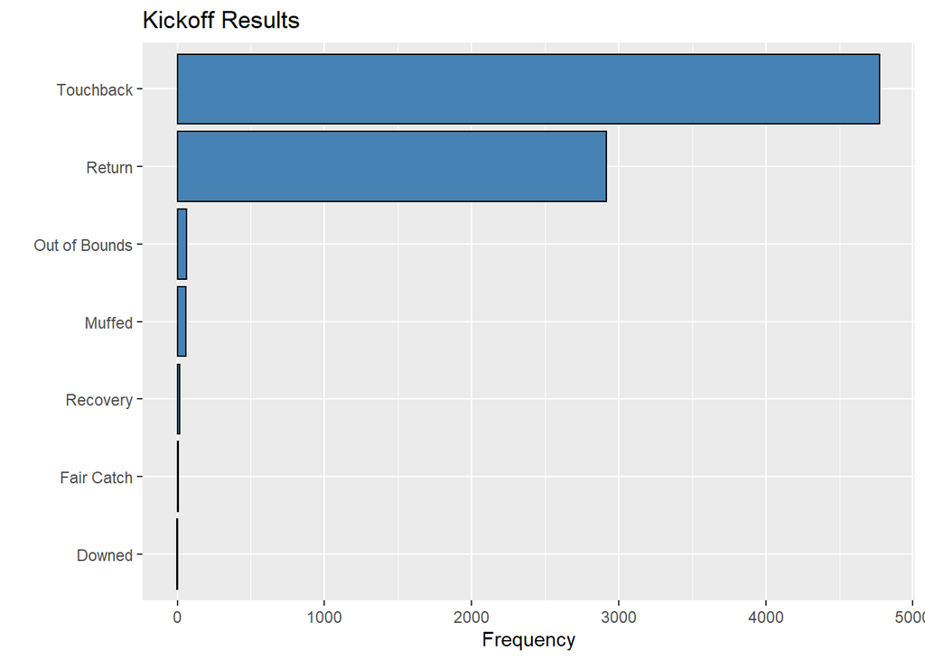

Figure 1: A bar chart of kickoff results. A majority of kickoffs result in touchbacks.

Even though most, if not all, NFL kickers and punters have the leg strength to kick touchbacks (i.e., kickoffs into the end zone that are placed on the receiving team’s 25yd line) it appears that there is a significant share of kickoff results are returns. This may indicate that a kickoff strategy for kickoff units is to intentionally kick returnable balls in an attempt to down the ball within the 25yd line. Since kicking teams prioritize downing the ball within the 25yd line, we will evaluate net yards (i.e., kicking yards minus return yards) for kickoffs in our model.

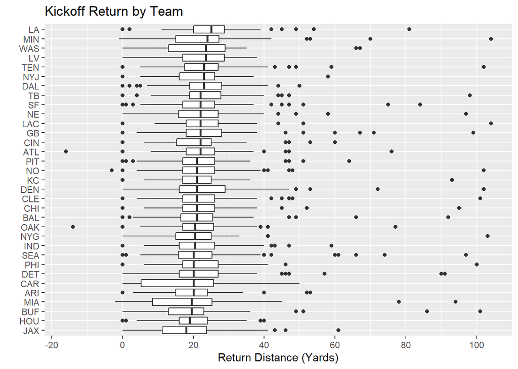

Figure 2: Boxplot of kickoff return distance by team.

This is more of an interesting fact pulled from the data, illustrating kickoff return performance by teams. Note that return distance is not equivalent to yard line because a kickoff can be fielded from a place other than the goal line. Negative return distances are the result of penalties from the receiving team.

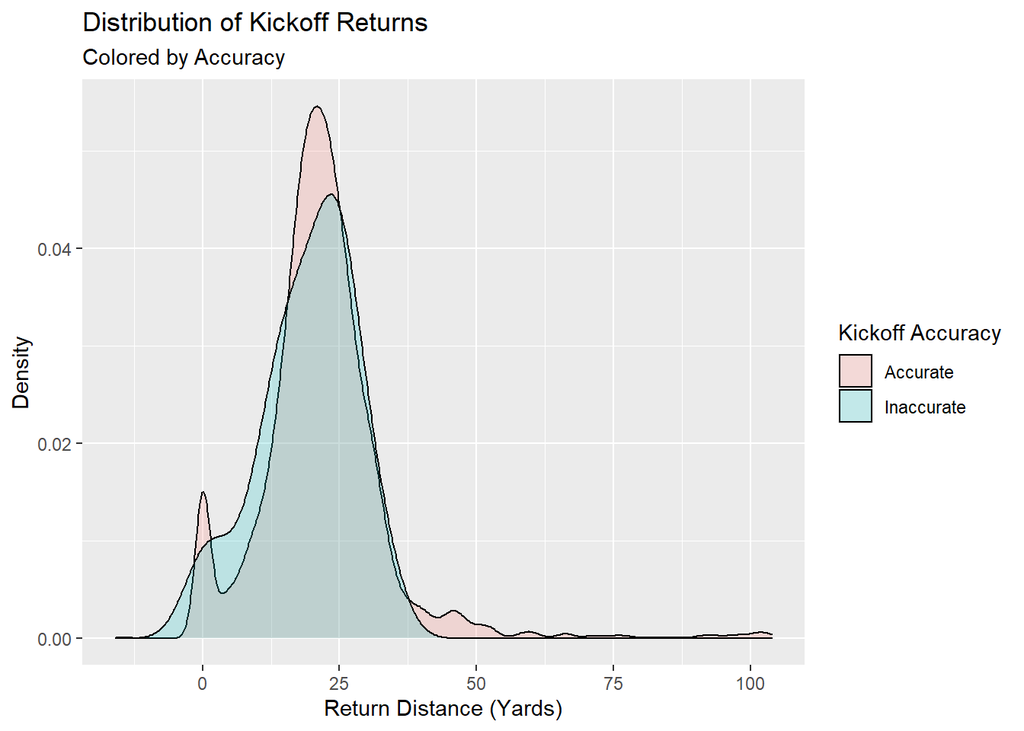

Kickoff accuracy is important for the coverage team’s coordination. However, it does not appear to have any notable differences in return distances for the receiving team. Also given that over 99% of kickoffs are accurate, accuracy is not a particularly meaningful variable that should be considered for our evaluation model.

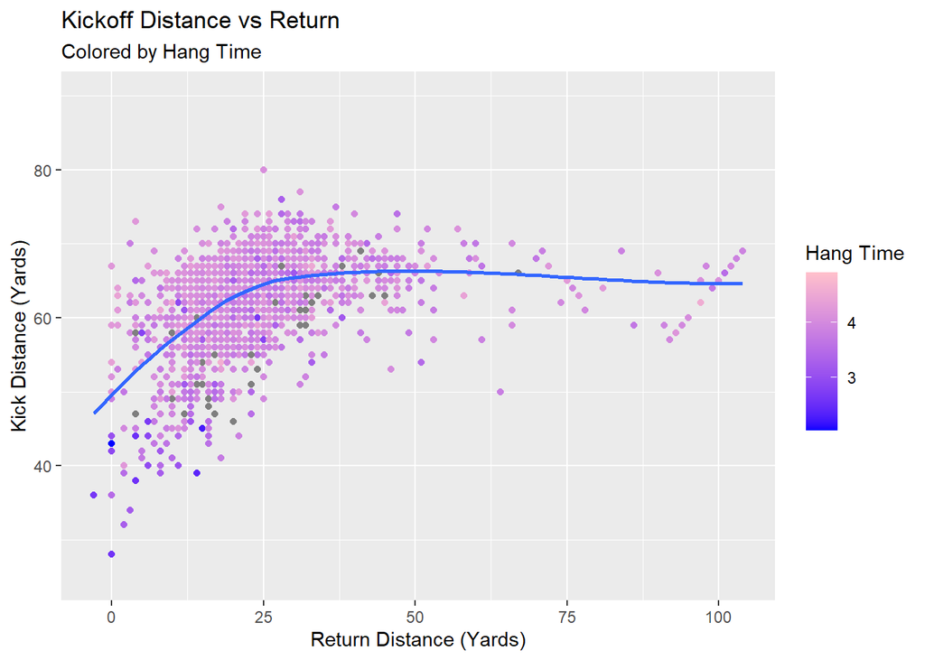

Figure 4: Scatterplot of kickoff distance against return distance colored by hang time.

While there is a positive relationship between kick distance and return distance, this does not mean teams are better off kicking short kickoffs. Farther kicks give returners more space to run but it also increases the kickoff’s net yardage which is ultimately most important for the kicking team. Since increased hang time gives the coverage team more time to travel downfield, our evaluation model for kickoffs should include net yardage and hang time.

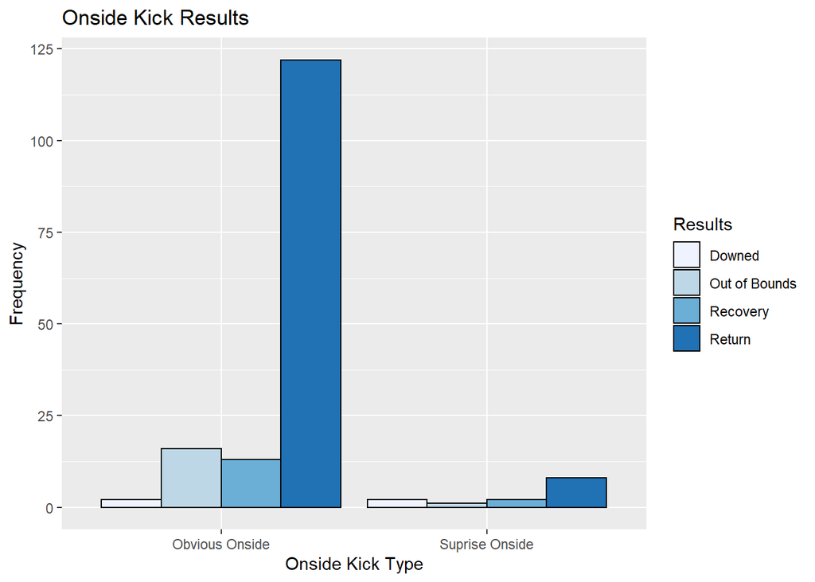

Figure 5: Bar chart of onside kick strategies grouped by results

In the NFL, teams kick onside kicks often as a last-ditch effort to regain possession of the ball after they score when they are trailing and there is little time remaining. Between the 2018 and 2020 seasons, approximately 9% of onside kicks were successfully recovered by the kicking team. Proportionately, there is no significant difference in the outcome of onside kicks (particularly recovery) regardless of whether they are obvious or a surprise. Therefore, one onside strategy does not stand out as better.

Although we performed EDA on onside kicks, they aren’t an appropriate metric to rank special teams players because in a single season some kickers don’t attempt any onside kicks, and even if they do it is not substantial (e.g., more than 5 onside kicks) for most players.

### Punt

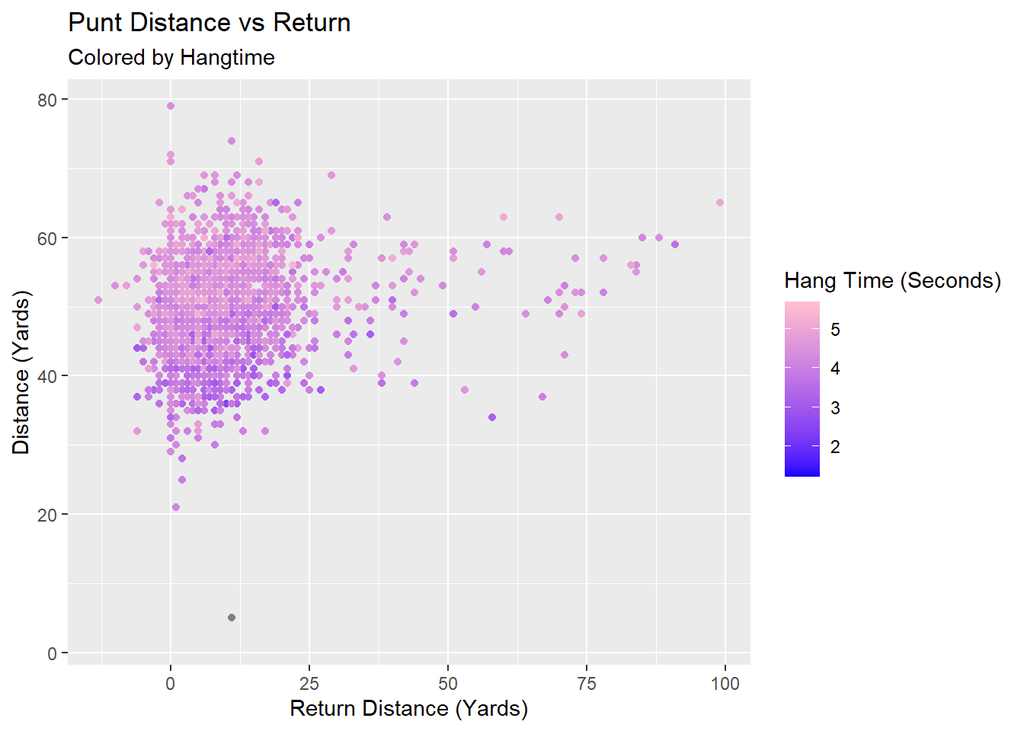

Figure 6: Scatterplot of punt and return distance colored by hang time.

It appears that the punt distance is directly associated with hang time and also has a weakly positive association with the return distance. However, this does not mean punters should avoid kicking deep punts. It’s highly probable that the fact that deep punts give returns more space to run is the factor motivating the weak positive relationship between punt and return distance.

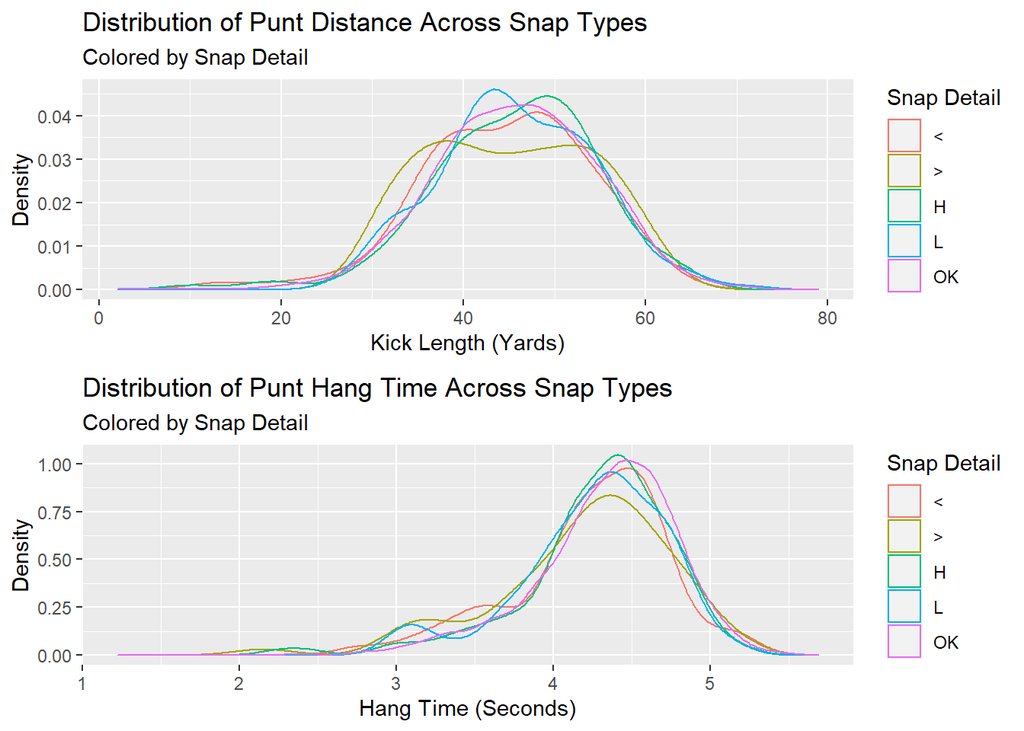

Figure 7: Probability density function of punt distance and hang time colored by snap detail.

The optimal placement for a snap is near the hip on your kicking side (e.g., at my right hip if I am a right-footed punter). Low snaps and snaps to the right appear to be associated with relatively less punt distance. However, there appears to be no significant differences in hang times across snap detail.

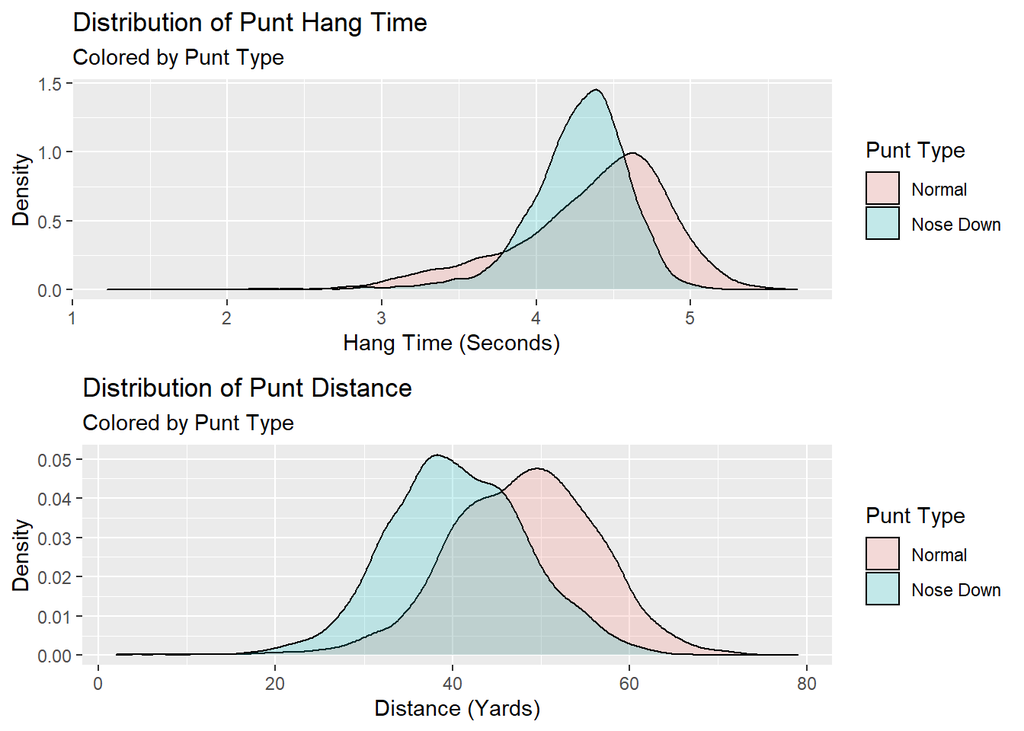

Figure 8: Probability density functions of the hang time and distance of nose down and normal punts.

Nose-down punts travel less distance and have less hang time, on average, compared to normal punts. Punters often use nose-down punts in short punt scenarios when they want to pin the ball within the 20yd line and the back spin of these punts helps prevent the ball from rolling into the end zone resulting in a touchback.

### Field Goal

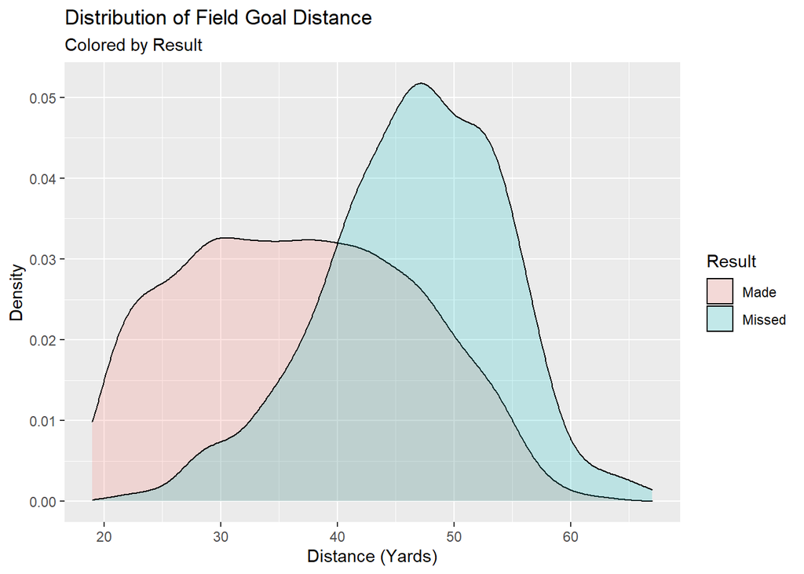

Figure 9: Probability density function of field goals across distances and grouped by accuracy.

As the field goal distance increases, the proportion of made field goals decreases. Leg strength is less of an issue relative to hooking the kick and being more susceptible to wind.

‘Clutchness’ is classified as the last five minutes of the first or second half while the score is within a field goal (i.e., difference in scores is $\leq 3$)

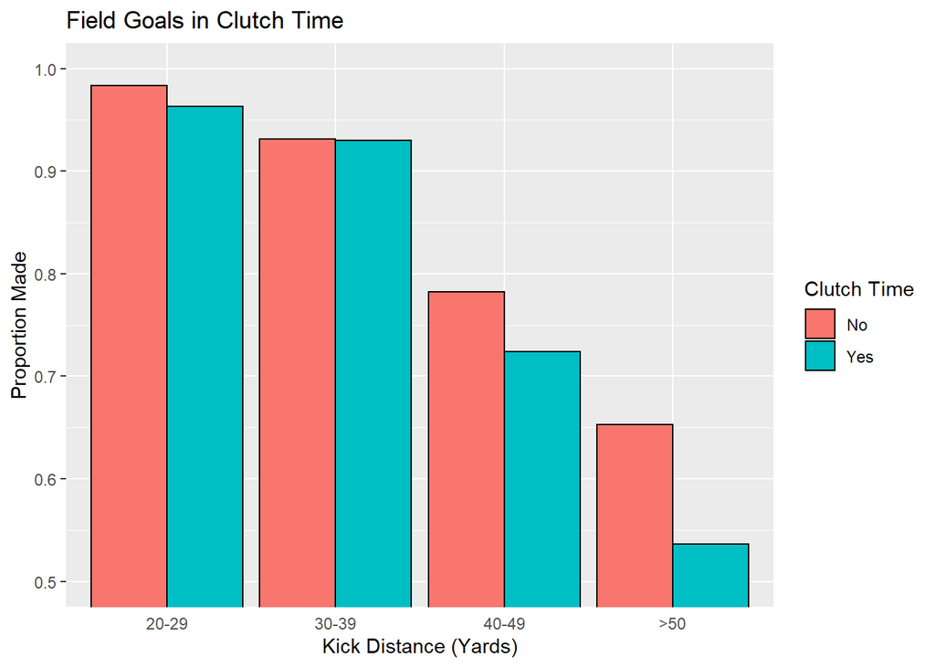

Figure 10: The proportion of field goals made in clutch time grouped by distance. There is a notable dropoff in field goal accuracy for 40-49yd and 50+yd field goals in clutch time.

The pressure of performing in clutch time situations can create an added burden on kickers. From this bar chart, we can see that as the kick distance increases the gap between conversion rates for kicks widens in clutch vs non-clutch time. This observation is especially prominent in 40-49yd and 50+yd field goals where we see conversion rates drop off noticeably in clutch time. Therefore, we should consider clutch time performance in our player ranking model for field goal kickers.

## Punter/Kicker Rating: PKR

Drawing inspiration from Total Quarterback Rating (QBR) we are developing a ranking system for punters and kickers.

For punters, this system takes into account net yards, hang time, inside 20 proportion, and blocked punts.

For field goal kickers, this system takes into account their field goal distance, accuracy, and performance in clutch time.

For kickoffs, this ranking system takes into account net yards, hang time, and whether the kickoff went out of bounds.

### Model

Our model applies weights to the standardized statistics to evaluate special teams players by play type (e.g., punt, field goal, kickoff).

By evaluating players on their statistics standardized by their position group’s performance, in a respective season, we can get a direct measure of how performances stack up against the field.

Given that some special team’s statistics are more important than others (e.g., net yards are more important than hang time for punts and kickoffs), we’ve applied weights to the standardized z-scores of each statistic.

The following are the model’s specifications:

$standardization \space is \space denoted \space as \space z \space such \space that: \space z = \frac{x_i-\mu}{\sigma}$

$weights \space are \space denoted \space as \space \beta \space terms \space such \space that: -1\leq\beta\leq1$

$punter \space rating = \beta_{p1} z(net \space yards) + \beta_{p2} z(hang \space time) + \beta_{p3} z(inside \space the \space 20\%) + \beta_{p4} z(blocked\%)$

$fg/xp \space rating = \beta_{f1} z(xp\%) + \beta_{f2}z(20-29\%) + \beta_{f3}z(30-39\%) + \beta_{f4}z(40-49\%) + \beta_{f5}z(\geq50\%) + \beta_{f6}z(clutch \space time\%)$

$kickoff \space rating = \beta_{k1}z(net \space yards) + \beta_{k2}z(hang \space time) + \beta_{k3}z(out \space of \space bounds\%)$

Tables 1-3 display the top 3 PKR rankings per season for punts, field goals, and kickoffs.

Table 1: Top 3 Punters Per Season

| Name | Attempts | Net Yards | Hang Time | In20Prop | Blocks (%) | PKR |
| --- | --- | --- | --- | --- | --- | --- |
| **2018** |  |  |  |  |  |  |
| Brett Kern | 73 | 43.04 | 4.20 | 0.52 | 0.01 | 2.38 |
| Cameron Johnston | 60 | 43.63 | 4.14 | 0.43 | 0.00 | 2.28 |
| Tress Way | 75 | 42.27 | 4.35 | 0.44 | 0.00 | 1.98 |
| **2019** |  |  |  |  |  |  |
| Bryan Anger | 43 | 45.58 | 4.43 | 0.40 | 0.00 | 2.67 |
| Tress Way | 76 | 45.01 | 4.37 | 0.41 | 0.00 | 2.39 |
| Logan Cooke | 70 | 44.77 | 4.45 | 0.33 | 0.00 | 1.81 |
| **2020** |  |  |  |  |  |  |
| Jake Bailey | 49 | 46.53 | 4.37 | 0.45 | 0.00 | 3.10 |
| Jack Fox | 56 | 44.55 | 4.54 | 0.41 | 0.00 | 2.54 |
| Michael Dickson | 56 | 45.00 | 4.28 | 0.46 | 0.00 | 2.43 |

Table 2: Top 3 Field Goal Kickers Per Season

| Name | Attempts | FG Accuracy | 20-29 (%) | 30-39 (%) | 40-49 (%) | >50 (%) | Clutch (%) | XP Accuracy | PKR |
| --- | --- | --- | --- | --- | --- | --- | --- | --- | --- |
| **2018** |  |  |  |  |  |  |  |  |  |
| Wil Lutz | 27 | 0.96 | 1 | 1.00 | 1.00 | 1.00 | 1.00 | 0.98 | 3.74 |
| Justin Tucker | 38 | 0.92 | 1 | 1.00 | 1.00 | 0.83 | 1.00 | 0.97 | 3.00 |
| Jason Sanders | 20 | 0.90 | 1 | 1.00 | 0.78 | 1.00 | 1.00 | 0.97 | 2.71 |
| **2019** |  |  |  |  |  |  |  |  |  |
| Justin Tucker | 29 | 0.97 | 1 | 1.00 | 0.91 | 1.00 | 1.00 | 0.96 | 3.41 |
| Josh Lambo | 31 | 0.97 | 1 | 1.00 | 0.88 | 1.00 | 1.00 | 0.95 | 3.11 |
| Zane Gonzalez | 31 | 0.90 | 1 | 0.92 | 0.83 | 1.00 | 1.00 | 0.97 | 2.46 |
| **2020** |  |  |  |  |  |  |  |  |  |
| Mason Crosby | 15 | 1.00 | 1 | 1.00 | 1.00 | 1.00 | 1.00 | 0.95 | 3.39 |
| Jason Sanders | 35 | 0.91 | 1 | 1.00 | 0.85 | 0.88 | 1.00 | 1.00 | 2.83 |
| Jason Myers | 20 | 1.00 | 1 | 1.00 | 1.00 | 1.00 | 0.81 | 0.91 | 2.47 |

Table 3: Top 3 Kickoff Kickers Per Season

| Name | Attempts | Net Yards | Hang Time | Out of Bounds (%) | PKR |
| --- | --- | --- | --- | --- | --- |
| **2018** |  |  |  |  |  |
| Ka’imi Fairbairn | 91 | 40.96 | 4.01 | 0.00 | 1.81 |
| Brandon McManus | 63 | 40.76 | 4.07 | 0.00 | 1.71 |
| Sam Martin | 69 | 41.16 | 3.85 | 0.00 | 1.60 |
| **2019** |  |  |  |  |  |
| Austin Seibert | 75 | 42.13 | 4.18 | 0.01 | 2.62 |
| Ka’imi Fairbairn | 80 | 42.04 | 4.13 | 0.00 | 2.61 |
| Younghoe Koo | 43 | 41.35 | 3.95 | 0.00 | 1.32 |
| **2020** |  |  |  |  |  |
| Zane Gonzalez | 61 | 42.26 | 4.00 | 0.00 | 2.41 |
| Tyler Bass | 99 | 41.49 | 4.07 | 0.00 | 1.90 |
| Jason Sanders | 84 | 41.23 | 4.08 | 0.01 | 1.45 |

### Limitations

1. **No Comparison Across Seasons**: PKR scores are dependent on the position group’s aggregate performance on a yearly basis, so it is possible that players with a PKR score of 3 in 2018 have better or worse statistics (e.g., net yards, hang time) than a player with the same PKR score in 2019. Therefore, by the virtue of standardizing the evaluation criteria by year, meaningful comparisons among players can not be made across seasons using the PKR.
2. **Inconsistent PKR Across Positions**: On average, field goal kickers will have a higher PKR score than punters because more criteria go into the evaluation score of kickers. Therefore, performance comparisons should only be made within position groups (e.g., comparing kickers with kickers and punters with punters).
3. **Arbitrary Weights**: Given that this data is unlabeled (i.e., plays are not labeled as ‘good’ or ‘bad’) and yardage from special teams plays are not significantly associated with any factors outside the punter and/or kicker’s leg strength, we were restricted from using supervised models to calculate PKR weights. We considered using an unsupervised neural network to calculate weights for our standardized statistics but this was not practical given the data and our problem statement. In turn, we utilize arbitrary weights that roughly capture the value of each statistic going into the PKR.